# Ejemplo de periodismo de datos con R

Isaac Gonzalez - www.datascience4business.com

# 1. PREPARACION DEL ANALISIS

El objetivo es aportar información rigurosa sobre el debate en cuanto al nivel impositivo de España:

- Analizando la presión fiscal (impuestos recaudados sobre el PIB)
- Analizando el esfuerzo fiscal (nivel de esfuerzo del contribuyente teniendo en cuenta su poder adquisitivo)
- En qué se invierte el dinero recaudado

# 2. ANALISIS DE LA PRESION Y ESFUERZO FISCAL

Fuente de los datos: https://www.elblogsalmon.com/indicadores-y-estadisticas/impuestos-esfuerzo-fiscal-espanoles-desmedido

Se ha utilizado tecnología OCR sobre la fuente citada para extraer los datos de la imagen y poder utilizarlos en los análisis.

Tras el proceso de extracción con OCR y una primera limpieza de datos hemos obtenido la siguiente tabla:

| pais | presion_valor | presion_ranking | esfuerzo_valor | esfuerzo_ranking |
| --- | --- | --- | --- | --- |
| Grecia | 0.4107 | 11 | 26.2760 | 1 |
| Portugal | 0.3653 | 13 | 20.2730 | 2 |
| Italia | 0.4291 | 9 | 16.1710 | 3 |
| Francia | 0.4707 | 1 | 13.9460 | 5 |
| España | 0.3574 | 15 | 15.1370 | 4 |
| Bélgica | 0.4621 | 2 | 12.0280 | 6 |
| Austria | 0.4384 | 4 | 10.6580 | Y |
| Finlandia | 0.4249 | 8 | 10.6450 | 8 |
| Alemania | 0.4190 | o | 10.4950 | 9 |
| Suecia | 0.4290 | 6 | 10.0000 | 11 |

[output cut: 10 more lines]

Vemos que en los rankings hay datos que el ocr no ha podido extraerlos bien.

Pero los valores sí parecen estar todos bien.

Así que vamos a generar de nuevo los rankings a partir de los valores.

Nos fijamos en que el valor 1 se le da al valor más alto en ambos casos.

| pais | presion_valor | presion_ranking | esfuerzo_valor | esfuerzo_ranking |
| --- | --- | --- | --- | --- |
| Grecia | 0.4107 | 12 | 26.2760 | 1 |
| Portugal | 0.3653 | 14 | 20.2730 | 2 |
| Italia | 0.4291 | 6 | 16.1710 | 3 |
| Francia | 0.4707 | 2 | 13.9460 | 5 |
| España | 0.3574 | 16 | 15.1370 | 4 |
| Bélgica | 0.4621 | 3 | 12.0280 | 6 |
| Austria | 0.4384 | 5 | 10.6580 | 7 |
| Finlandia | 0.4249 | 9 | 10.6450 | 8 |
| Alemania | 0.4190 | 10 | 10.4950 | 9 |
| Suecia | 0.4290 | 7 | 10.0000 | 11 |

[output cut: 10 more lines]

Ahora ya pasamos a la fase de visualización.

Analizamos primero como está España en cuanto a presión fiscal (impuestos recaudados / PIB)

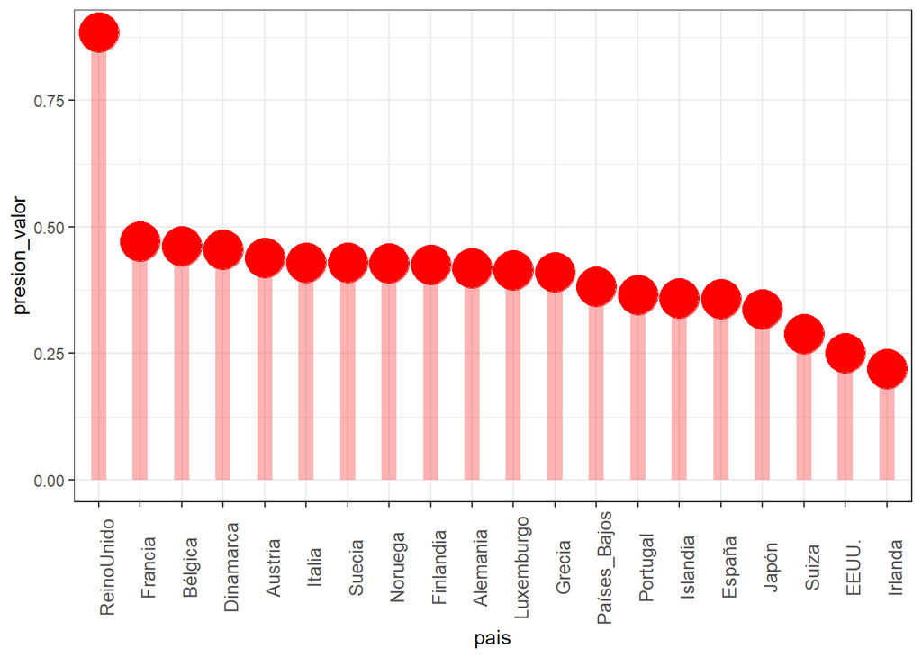

Pero ahora vemos el esfuerzo fiscal (ajuste por renta per capita)

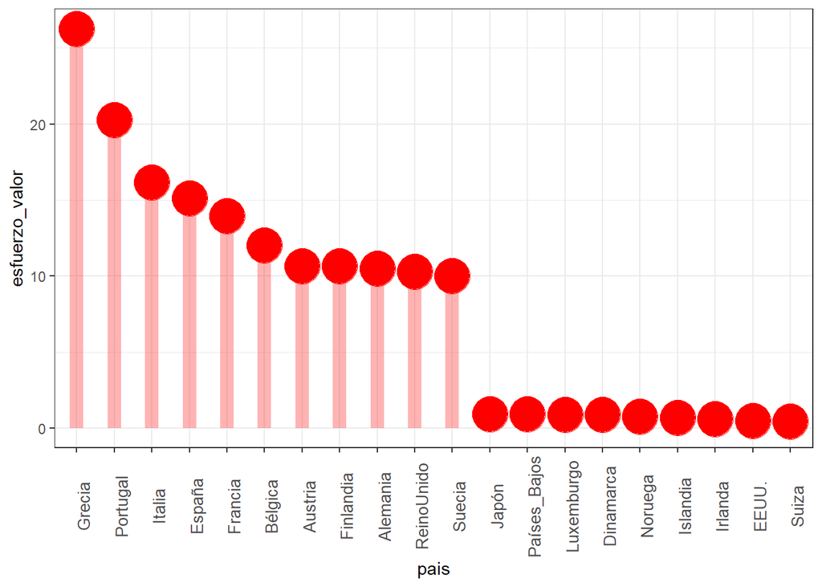

Y ahora vamos a crear un mapa de posicionamiento con los 2 indicadores a la vez

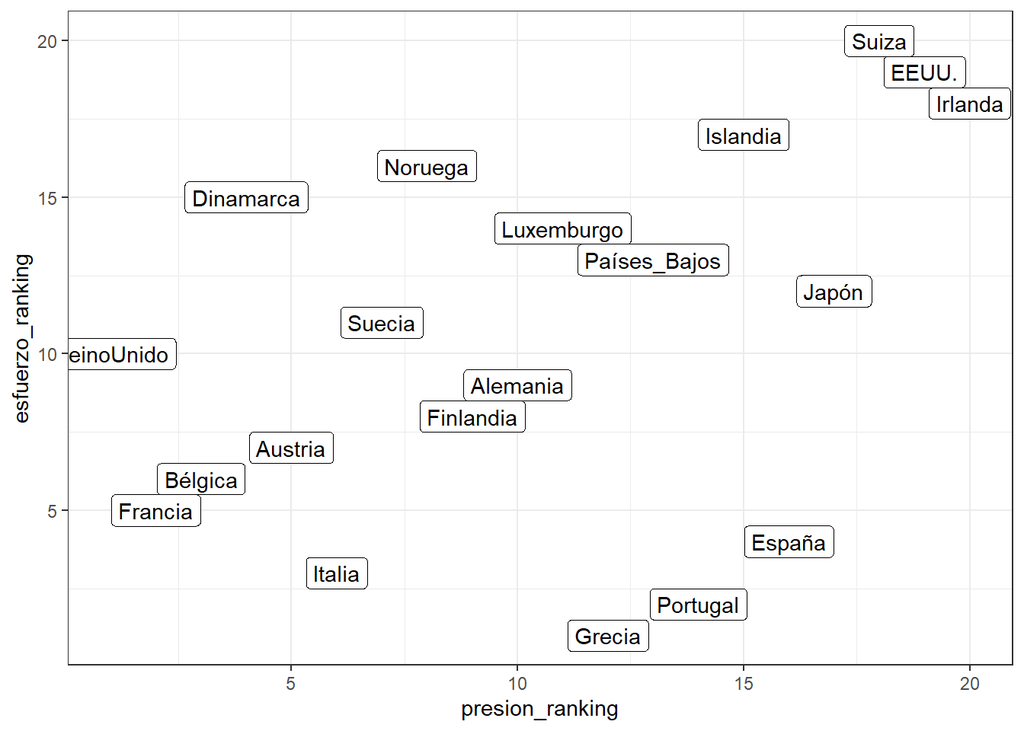

# 3. ANALISIS DE LAS PARTIDAS DEL GASTO

Parece que aunque a nivel del indicador de presión fiscal España todavía tendría recorrido para subir impuestos, cuando analizamos el esfuerzo real que los impuestos actuales ya suponen para el contribuyente solo hay 3 países por encima de España.

En muchos casos se justifica ese esfuerzo alegando que es necesario para mantener servicios como la sanidad, la educación o la protección social.

Vamos a visualizar cómo se distribuyen las partidas del gasto público según datos del Ministerio de Hacienda obtenidos de:

https://www.epdata.es/datos/gasto-publico-espana-datos-graficos/256

A partir de la fuente citada y limpiando y organizando los datos obtenemos la siguiente tabla:

| ano | partida | gasto | total | porc | porc_acum |
| --- | --- | --- | --- | --- | --- |
| 2018 | proteccion_social | 203116 | 501497 | 40.501937 | 40.50194 |
| 2018 | salud | 72017 | 501497 | 14.360405 | 54.86234 |
| 2018 | servicios_publicos_generales | 67705 | 501497 | 13.500579 | 68.36292 |
| 2018 | asuntos_economicos | 48909 | 501497 | 9.752601 | 78.11552 |
| 2018 | educacion | 48095 | 501497 | 9.590287 | 87.70581 |
| 2018 | orden_publico_y_seguridad | 21997 | 501497 | 4.386268 | 92.09208 |
| 2018 | ocio_cultura_y_religion | 13353 | 501497 | 2.662628 | 94.75470 |
| 2018 | proteccion_del_medio_ambiente | 10604 | 501497 | 2.114469 | 96.86917 |
| 2018 | defensa | 10283 | 501497 | 2.050461 | 98.91963 |
| 2018 | vivienda_y_servicios_comunitarios | 5418 | 501497 | 1.080365 | 100.00000 |

Que podemos ver de forma gráfica

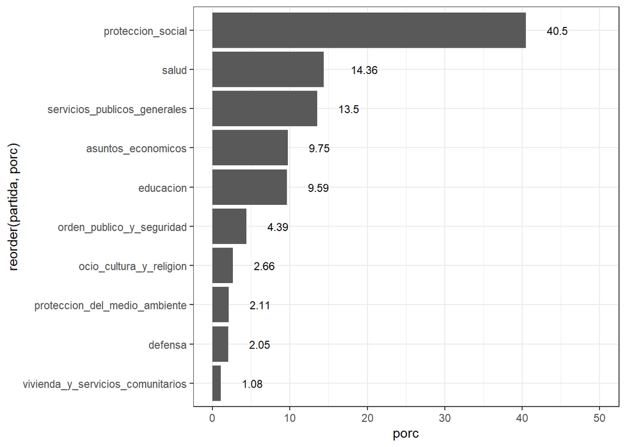

# 4. CONCLUSIONES

- La presión fiscal en España es de las más bajas, ocupando el puesto 16 en un ranking de 20 países
- Sin embargo, el esfuerzo real para los contribuyentes es de los mayores, ocupando el puesto 4 en un ranking de 20 países
- El gasto de sanidad + educación suma el 23.95 por ciento
- Y si añadimos protección social suma el 64.45 por ciento
- QUE CADA UNO SAQUE SUS PROPIAS CONCLUSIONES!!!